# SAS function Intro

author

2022-09-08

# [SAS Functions and CALL Routines](https://documentation.sas.com/doc/en/pgmsascdc/9.4_3.5/lefunctionsref/titlepage.htm)

- A function is a component of the SAS programming language that can accept **arguments**, perform a computation or other operation, and **return a value**.
- A CALL routine alters variable values or performs other system functions. CALL routines are similar to functions, but differ from functions in that you cannot use them in assignment statements or expressions.

## Syntax of Functions and CALL Routines

- `function-name (argument-1<, ...argument-n>)`
- `function-name (OF variable-list)`
- `function-name (<argument | OF variable-list | OF array-name[*]>)`

## Function arguments

- constants, `abs(-1)`
- variables, `int(cash)`
- expressions, `min((enroll-drop),(enroll-fail))`
- other functions, `left(upcase(City))`

## Variable-list

- numbered range lists, `sum(of y1-y10)`
- name range lists, `studid--usubjid`
- Name Prefix Lists, `sum(of Sales:)`
- Special SAS Name Lists
  - `_NUMERIC_`, all numeric variables that are already defined in the current DATA step
  - `_CHARACTER_`, all character variables that are already defined in the current DATA step
  - `_ALL_`, all variables that are already defined in the current DATA step `cmiss(of _ALL_)=0`

## Function type

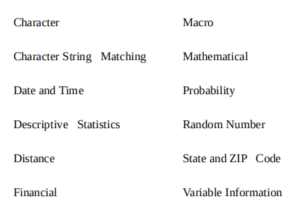

## Functions and Procedures

Functions in **DATA STEP** row-wise operations

```sas
data class;
    set sashelp.class;
    mean_of_height_weight = mean(height, weight);;
run;
```

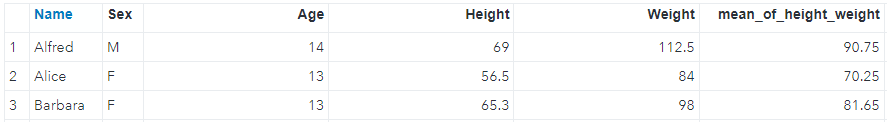

Procedures column-wise operations

```sas
proc means data=sashelp.class mean;
    var height;
run;
```

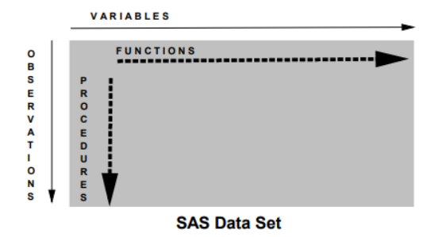

Functions in **PROC SQL**

```sas
proc sql;
    select mean(height) as mean_of_height
    from sashelp.class;
quit;
```

```sas
proc sql;
    select height, weight, mean(height,weight) as mean_of_height_weight
    from sashelp.class
    ;
quit;
```

## Pop-up Syntax Help

- SAS Enterprise Guide
- SAS Studio
- Official SAS Language Extension for VS Code

[figure not shown]

# Character Functions

## RANK and BYTE

- RANK: Returns the position of a character in the ASCII collating sequence

  ```sas
    data _null_
        n=rank('A');
        put n;
    run;
    /* n = 65 */
  ```

- BYTE: Returns one character in the ASCII collating sequence

  ```sas
    data _null_;
        x=byte(80);
        put x;
    run;
    /* x = P */
  ```

- Check special characters

## Concatenating Strings

- Concatenation operator (either `||` or `!!`): not remove blanks and the length

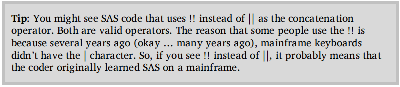

- CAT() functions: stripping leading and trailing spaces and converting numbers to characters

```sas
/*
newString = trim(left(string1)) || left(string2)
newString = cats(string1, string2)

newString = trim(left(string1)) || left(put(number, 10.));
newString = cats(string1, number);
*/
```

- Concatenating Strings with a Delimiter

```sas
/*
newString = trim(left(string1)) || " " || left(string2);
newString = catx(" ", string1, string2);
*/

/* CATX() only puts the delimiter between non-blank values */
data test;
    string1 = " ";
    string2 = "A";
    string3 = "";
    string4 = "B";
    newString1 = string1 || "," ||string2 ||","|| string3 ||","||string4;
    newString2 = catx(",", of string:); /* variable list */
    newString3 = catx(",", of _all_);
run;
```

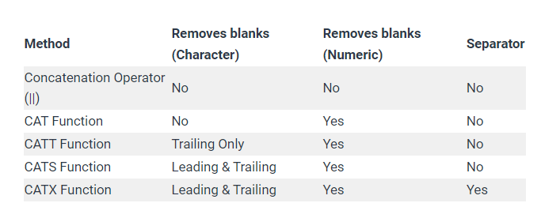

## Removing Leading and Trailing Spaces

- `LEFT`: removes leading blanks
- `TRIM`: removes the trailing blanks
- `TRIMN`: removes trailing blanks from character expressions and returns a string with a length of zero if the expression is missing.
- `STRIP`: removes all leading and trailing blanks and returns a string with a length of zero on a blank string

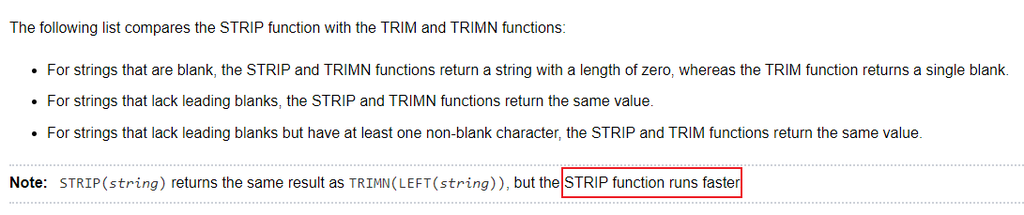

## Finding Non-Blank Values

## Character cases

- LOWCASE: converts all characters of a string to lowercase
- UPCASE: converts all characters of a string to uppercase
- PROPCASE: converts the string to proper case, capitalize the first letter of each word
- ANYLOWER: returns the position of the first lowercase character of a string
- NOTLOWER: returns the position of the first not lowercase character of a string
- ANYUPPER: returns the position of the first uppercase character of a string
- NOTUPPER: returns the position of the first not uppercase character of a string

```sas
data test;
    string="this iS a string";
    lower_case = lowcase(string);
    upper_case = upcase(string);
    proper_case = propcase(string);
    any_lower = anylower(string);
    not_lower = notlower(string);
    any_upper = anyupper(string);
    not_upper = notupper(string);
run;
```

## SAS K Functions

# Numeric Functions

# Date and time functions